# Avocado Price Populations

```python
import pandas as pd
import numpy as np
import matplotlib.pyplot as plt
import seaborn as sns
from scipy import stats
```

```python
data = pd.read_csv('clean_data.csv')
```

## What we already know

- Each year has a different distriubtion in AveragePrice
- Each type has a different distriubion of AveragePrice

```python
#grouping to get sample means
sample_means = (data.groupby(['year','type'])['AveragePrice'].mean())
sample_means = sample_means.unstack()
```

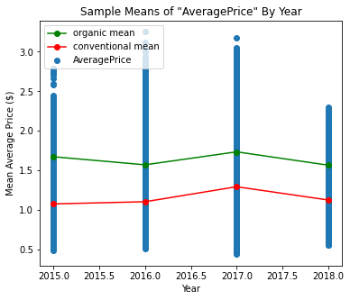

```python
fig = plt.figure(figsize=(6,5))
plt.scatter(data = data,x='year',y='AveragePrice')
sample_means['organic'].plot(marker='o',color='g',label='organic mean')
sample_means['conventional'].plot(color='r',marker='o',label='conventional mean')
plt.title('Sample Means of "AveragePrice" By Year')
plt.ylabel('Mean Average Price ($)')
plt.xlabel('Year')
plt.legend()
plt.show()
```

as we can see for each year there is a bimodal distriubtion due to the two types of avocados. organic and conventional

# Estimating the Expected Value of AveragePrice

```python
type_ = ['conventional','organic']
samples ={}
#create a dictionary with each sample based on year and type
for i in range(data['year'].min(),data['year'].max()+1):

    for t in type_:
        samples['{} {}'.format(i,t)]=(data.loc[(data['year']==i)&(data['type']==t),'AveragePrice'])
```

## Distribution of Sub Groups from each Sub Population

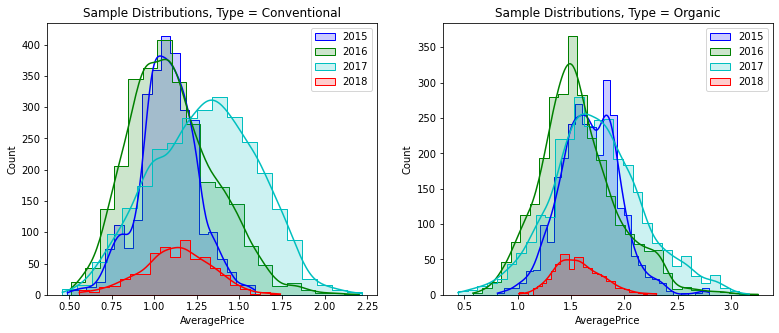

```python
col =['b','g','c','r']

fig,(ax1,ax2) = plt.subplots(1,2,figsize=(13,5))

for c,i in enumerate(range(2015,2019)):
    sns.histplot(x =samples['{} conventional'.format(i)],alpha=0.2,kde=True,stat='count',element="step",color='{}'.format(col[c]),label = '{}'.format(i),ax=ax1,bins=20)
    sns.histplot(x =samples['{} organic'.format(i)],alpha=0.2,kde=True,stat='count',element="step",color='{}'.format(col[c]),label = '{}'.format(i),ax=ax2,bins=30)

ax1.legend()
ax2.legend()

ax1.set_title('Sample Distributions, Type = Conventional')
ax2.set_title('Sample Distributions, Type = Organic')

plt.show()
```

All the distributions take on a unimodal distribution, based on the histograms i would assume that the population distribution would be normal. Either way this does not matter for the next stage, where i will estimate the true population mean of each sample. because i am making this estimate based on the mean of the sampling mean. the distribution of the sampling mean will always be normal.

## Stratified Random Sampling

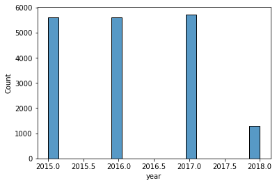

```
2017    5722
2016    5616
2015    5615
2018    1296
Name: year, dtype: int64
```

```python
sns.histplot(data['year'])
plt.show()
data['year'].value_counts()
```

```python
_2015_sample = data.loc[((data['year']==2015)&(data['type']=='conventional')),'AveragePrice'].sample(n=600,random_state=1)
_2015_sample = data.loc[((data['year']==2016)&(data['type']=='conventional')),'AveragePrice'].sample(n=600,random_state=2)
_2017_sample = data.loc[((data['year']==2017)&(data['type']=='conventional')),'AveragePrice'].sample(n=600,random_state=3)
_2018_sample = data.loc[((data['year']==2018)&(data['type']=='conventional')),'AveragePrice'].sample(n=600,random_state=4)

_2015_sample2 = data.loc[((data['year']==2015)&(data['type']=='organic')),'AveragePrice'].sample(n=600,random_state=1)
_2015_sample2 = data.loc[((data['year']==2016)&(data['type']=='organic')),'AveragePrice'].sample(n=600,random_state=2)
_2017_sample2 = data.loc[((data['year']==2017)&(data['type']=='organic')),'AveragePrice'].sample(n=600,random_state=3)
_2018_sample2 = data.loc[((data['year']==2018)&(data['type']=='organic')),'AveragePrice'].sample(n=600,random_state=4)
```

### Estimating E(X) AveragePrice for sub populations organic and conventional

$ \mu_\bar{X} =E(X) $

$\sigma_\bar{X} = \frac{\sigma}{\sqrt{n}}$

We dont know the population standard devition but we can estimate it given n is large enough.

$\sigma_\bar{X} \approx \frac{S}{\sqrt{n}} $

99% of all the means are within $3\sigma$ of $ \mu_\bar{X}$ or $E(X)$

```python
#sample 1 statistics.
x1 = _2015_sample.append(_2015_sample.append(_2017_sample.append(_2018_sample)))
x1_mean = x1.mean()
x1_n = x1.shape[0]
s1 = np.sqrt(((x1 - x1_mean)**2).sum()/(x1_n - 1))
#sample1 estimation
est_std_xbar = s1/(np.sqrt(x1_n))
_99confidance = est_std_xbar*3

#sample 2 statistics.
x2 = _2015_sample2.append(_2015_sample2.append(_2017_sample2.append(_2018_sample2)))
x2_mean = x2.mean()
x2_n = x2.shape[0]
s2 = np.sqrt(((x2 - x2_mean)**2).sum()/(x2_n - 1))
#sample 2 estimations.
est_std_xbar2 = s2/(np.sqrt(x2_n))
_99confidance2 = est_std_xbar2*3
```

```python
print('99% conf. That the Expected Value of Average Price, for conventional avocados is between $',round(x1_mean -_99confidance,2),'and $',round(x1_mean +_99confidance,2))
print('99% conf. That the Expected Value of Average Price, for organic avocados is between $',round(x2_mean -_99confidance2,2),'and $',round(x2_mean +_99confidance2,2))
```

```
99% conf. That the Expected Value of Average Price, for conventional avocados is between $ 1.14 and $ 1.18
99% conf. That the Expected Value of Average Price, for organic avocados is between $ 1.6 and $ 1.64
```